# Assignment #2 — Statistical analysis of thermal comfort research

- Show All Code
- Hide All Code
- View Source

Author

Kaito Funada

Published

September 27, 2026

```r
library(ggplot2)
library(dplyr)
library(tidyr)

theme_set(theme_minimal(base_size = 12))

load("data/arch241a2.rda")
d <- arch241a2
```

## About this dataset — read before you start

Thirty subjects each sat through seven conditions in a climate chamber in Guangzhou, giving 30 × 7 = 210 rows.

| Variable | Meaning | Notes |
| --- | --- | --- |
| `Top` | Operative temperature, °C | Equals air temperature here (MRT = Ta) |
| `RH` | Relative humidity, % | Two levels: 50 and 70 |
| `Sex` | F / M | 15 subjects each |
| `Subject` | Subject ID, 1–30 | Each ID appears 7 times |
| `TS` | Thermal sensation | ASHRAE scale, −4 cold … 0 neutral … +4 hot |
| `TC` | Thermal discomfort | 0 = very comfortable … 4 = very uncomfortable |
| `TA` | Thermal acceptability | Higher = more acceptable |
| `PMV` | Predicted mean vote | Calculated from the design conditions |
| `PPD` | Predicted % dissatisfied | Calculated from PMV |
| `Experiment` | Condition A–F, plus P | P is pre-conditioning, not a test condition |

```r
str(d)
```

```
'data.frame':   210 obs. of  10 variables:
 $ Top       : num  20 20 20 20 20 20 20 20 20 20 ...
 $ RH        : num  50 50 50 50 50 50 50 50 50 50 ...
 $ Sex       : Factor w/ 2 levels "F","M": 1 1 1 1 1 1 1 1 1 1 ...
 $ Subject   : Factor w/ 30 levels "1","10","11",..: 1 12 23 25 26 27 28 29 30 2 ...
 $ TS        : num  -1.32 -0.79 -2.82 -2.55 -1.26 -1.94 -2.16 -3.44 -2.35 -1.9 ...
 $ TC        : num  1.73 2.19 3.73 3.41 3.11 2.54 3.09 3.49 2 3.49 ...
 $ TA        : num  0.31 0.54 -0.84 -0.71 -0.4 -0.3 -0.29 -0.76 0.24 -0.88 ...
 $ PMV       : num  -1.9 -1.9 -1.9 -1.9 -1.9 -1.9 -1.9 -1.9 -1.9 -1.9 ...
 $ PPD       : num  78 78 78 78 78 78 78 78 78 78 ...
 $ Experiment: Factor w/ 7 levels "A","B","C","D",..: 1 1 1 1 1 1 1 1 1 1 ...
```

## 1. Statistical summary of all variables

```r
#  Summarise every variable.
summary(d)
```

```
      Top              RH        Sex        Subject          TS
 Min.   :20.00   Min.   :50.00   F:105   1      :  7   Min.   :-3.4400
 1st Qu.:23.00   1st Qu.:50.00   M:105   10     :  7   1st Qu.:-0.6325
 Median :29.00   Median :50.00           11     :  7   Median : 0.1500
 Mean   :27.29   Mean   :55.71           12     :  7   Mean   : 0.1781
 3rd Qu.:32.00   3rd Qu.:70.00           13     :  7   3rd Qu.: 1.1375
 Max.   :32.00   Max.   :70.00           14     :  7   Max.   : 3.6600
                                         (Other):168
       TC              TA               PMV            PPD        Experiment
 Min.   :0.310   Min.   :-0.8800   Min.   :-1.9   Min.   : 5.00   A:30
 1st Qu.:1.587   1st Qu.:-0.0800   1st Qu.:-0.9   1st Qu.:24.00   B:30
 Median :1.935   Median : 0.2350   Median : 1.2   Median :45.00   C:30
 Mean   :2.064   Mean   : 0.2268   Mean   : 0.7   Mean   :52.71   D:30
 3rd Qu.:2.442   3rd Qu.: 0.6475   3rd Qu.: 2.3   3rd Qu.:88.00   E:30
 Max.   :3.730   Max.   : 0.9800   Max.   : 2.6   Max.   :94.00   F:30
                                                                  P:30
```

```r
# Think: does a mean make sense for a factor? For a design variable like Top?
```

**Interpretation.** [WRITE 2–3 SENTENCES. What would you put in a paper?] The dataset contains 210 observations from 30 subjects across 7 experimental conditions. The sample includes 15 female and 15 male subjects. Operative temperature ranges from 20 to 32 °C, and thermal sensation ranges from -3.44 to 3.66.

## 2. Histograms of TC and TS

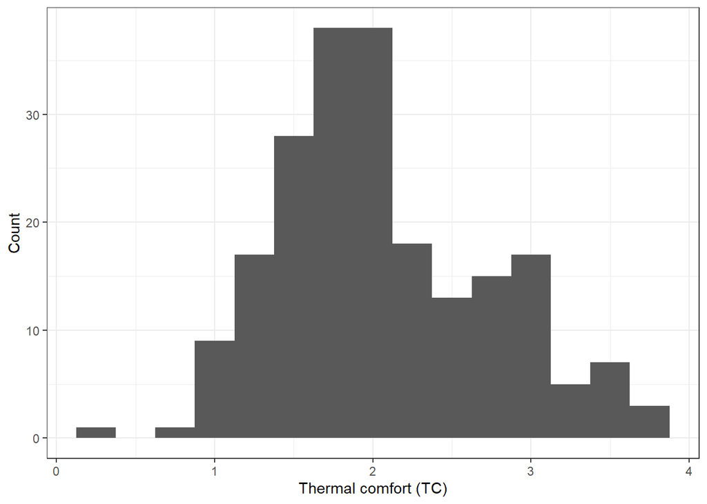

```r
qplot(TC, data=arch241a2, geom="histogram", binwidth=0.25) +
  xlab("Thermal comfort (TC)") +
  ylab("Count") +
  theme_bw()
```

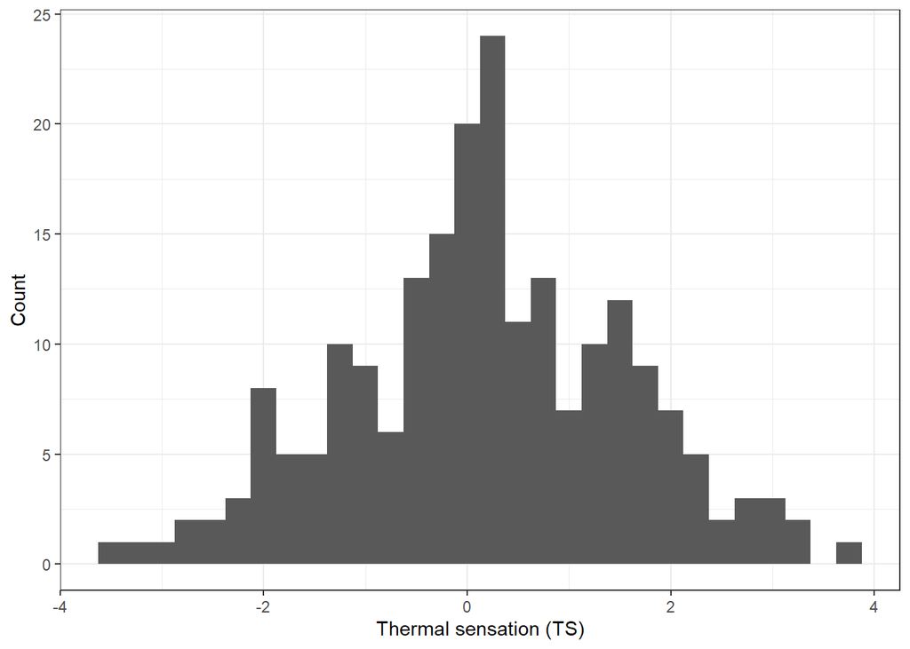

```r
qplot(TS, data=arch241a2, geom="histogram", binwidth=0.25) +
  xlab("Thermal sensation (TS)") +
  ylab("Count") +
  theme_bw()
```

**Interpretation.** [WRITE 2–3 SENTENCES] TS appears roughly symmetric, while TC looks not symmetric distribution. This suggests that TS is closer to a normal distribution than TC.

## 3. Boxplots of TS vs Sex, Subject and Experiment

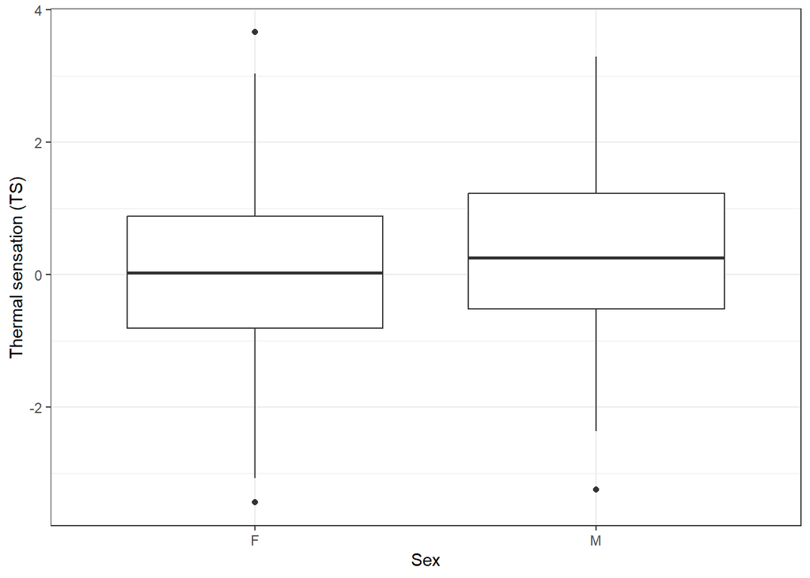

```r
# [WRITE YOUR CODE] Three plots.
qplot(Sex, TS, data=arch241a2, geom="boxplot") +
  xlab("Sex") +
  ylab("Thermal sensation (TS)") +
  theme_bw()
```

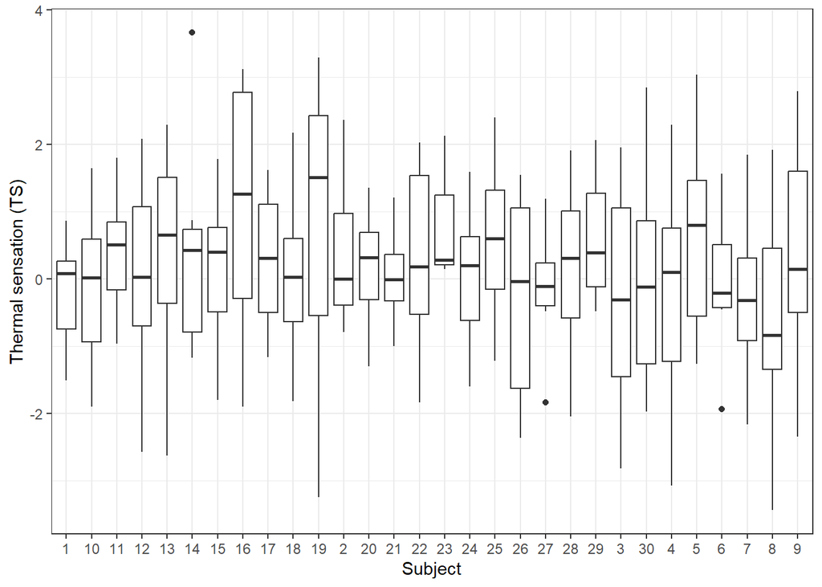

```r
qplot(Subject, TS, data=arch241a2, geom="boxplot") +
  xlab("Subject") +
  ylab("Thermal sensation (TS)") +
  theme_bw()
```

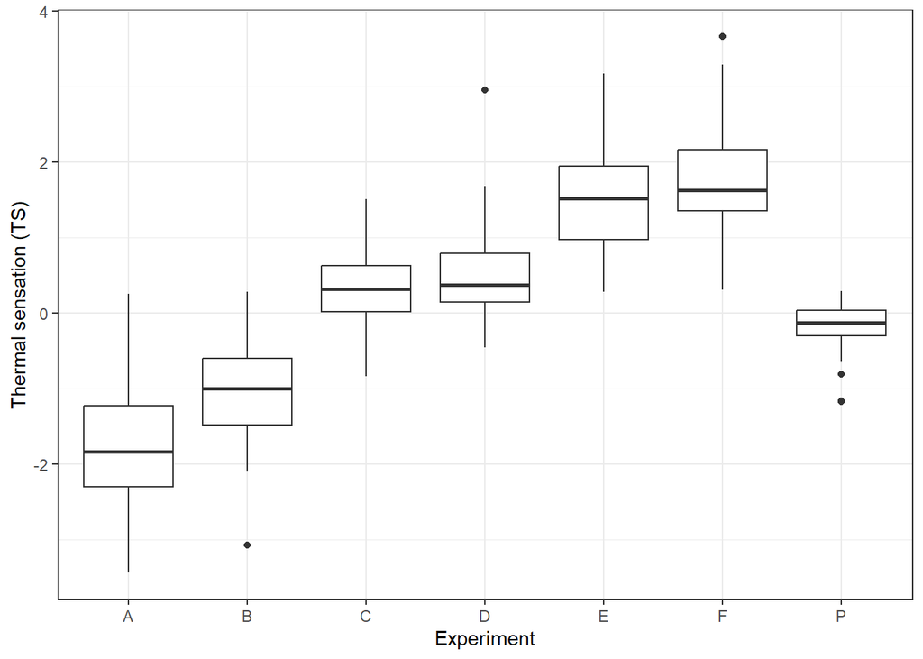

```r
qplot(Experiment, TS, data=arch241a2, geom="boxplot") +
  xlab("Experiment") +
  ylab("Thermal sensation (TS)") +
  theme_bw()
```

```r
# The Subject one is the least obvious and the most informative — look at it carefully.
```

**Interpretation.** [WRITE 2–3 SENTENCES] TS difference is almost same between female and male. Almost all TS scatters around 0 for all subject, but not sure if there is a significant difference. TS looks different among each experiment condition.

## 4. Correlation matrix

Variables: PMV, PPD, RH, TA, TC, TS, Top.

```r
# [WRITE YOUR CODE]
corrTab <- cor(
  arch241a2[,c("PMV","PPD","RH","TA","TC","Top","TS")],
  use="complete",
  method="pearson"
)

round(corrTab,2)
```

```
      PMV   PPD    RH    TA    TC   Top    TS
PMV  1.00  0.37  0.54 -0.14  0.16  1.00  0.87
PPD  0.37  1.00  0.33 -0.58  0.60  0.34  0.38
RH   0.54  0.33  1.00 -0.16  0.18  0.48  0.47
TA  -0.14 -0.58 -0.16  1.00 -0.85 -0.13 -0.20
TC   0.16  0.60  0.18 -0.85  1.00  0.14  0.21
Top  1.00  0.34  0.48 -0.13  0.14  1.00  0.87
TS   0.87  0.38  0.47 -0.20  0.21  0.87  1.00
```

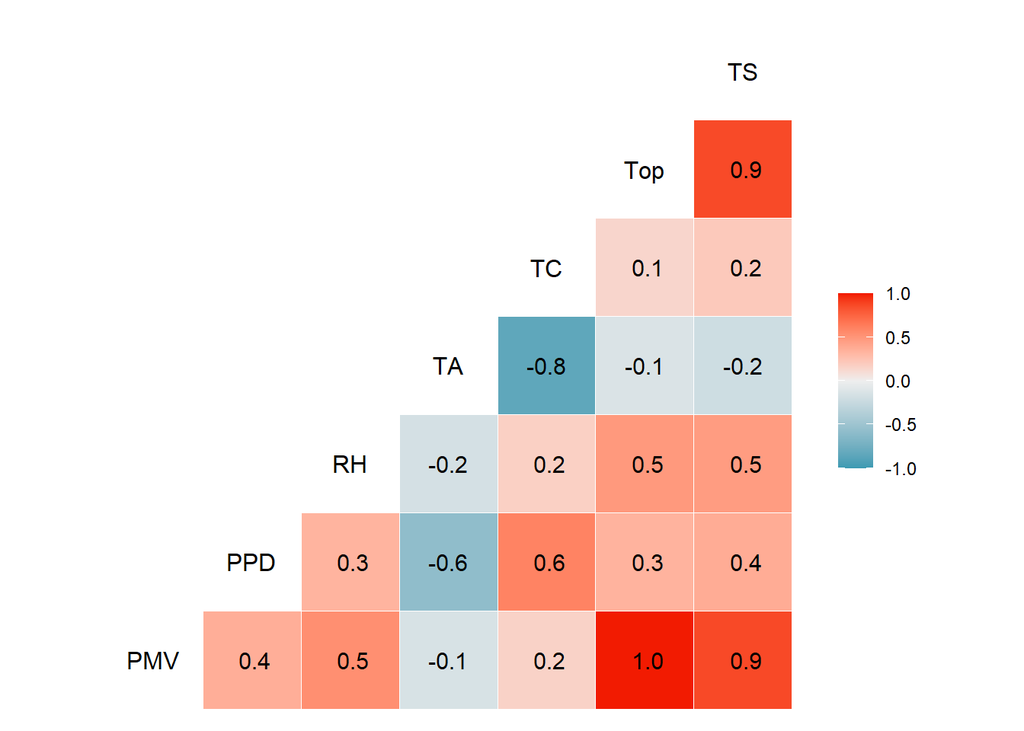

```r
library('GGally')

ggcorr(
  arch241a2[,c("PMV","PPD","RH","TA","TC","Top","TS")],
  label=TRUE
)
```

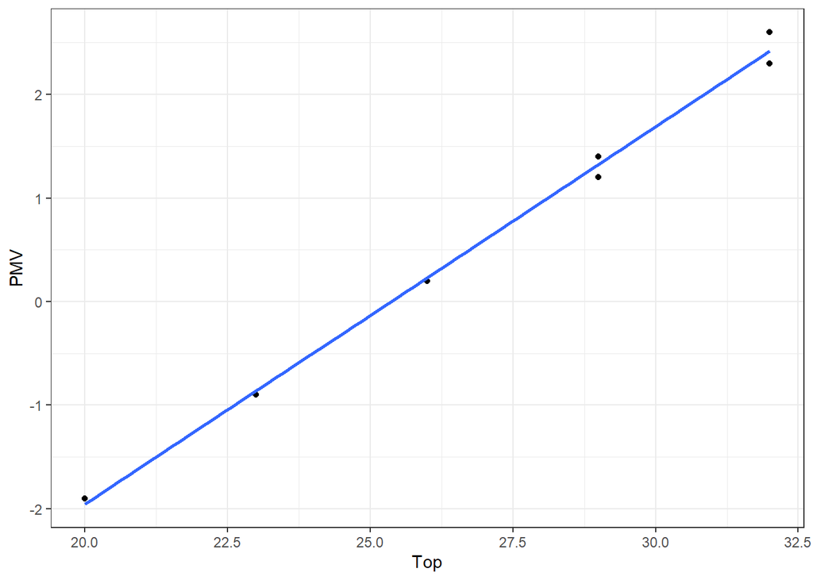

```r
# Top vs PMV
ggplot(
  distinct(arch241a2, Top, PMV),
  aes(x=Top, y=PMV)
) +
  geom_point() +
  geom_smooth(method="lm", se=FALSE) +
  theme_bw()
```

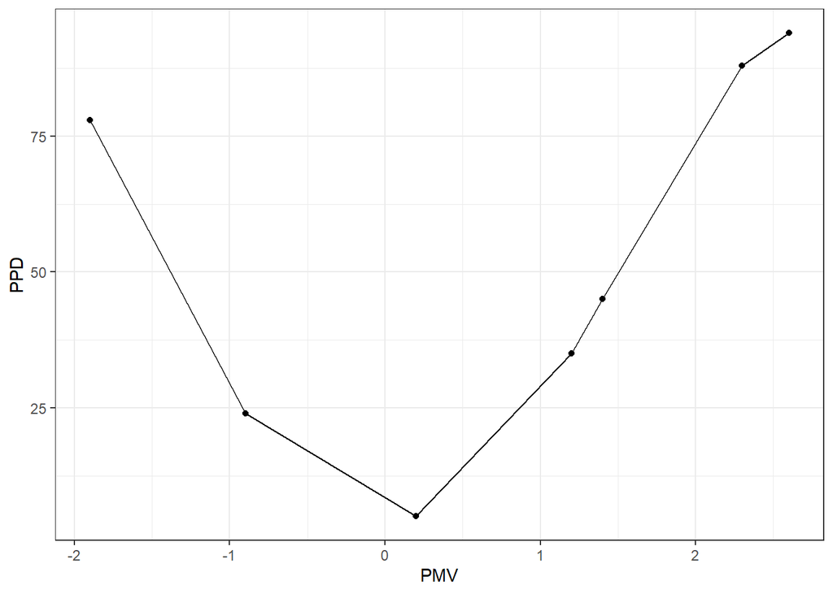

```r
# PMV vs PPD
ggplot(
  distinct(arch241a2, PMV, PPD),
  aes(x=PMV, y=PPD)
) +
  geom_point() +
  geom_line() +
  theme_bw()
```

**Interpretation.** [WRITE 2–3 SENTENCES] TS is strongly positively correlated with Top (r = 0.87) and PMV (r = 0.87). TC and TA are strongly negatively correlated (r = -0.85).

Top and PMV are almost perfectly correlated because PMV was calculated from the experimental thermal conditions. In contrast, PMV and PPD are deterministically related but their correlation is only 0.37 because their relationship is nonlinear (U curve) rather than linear.

## 5. Normality of TC and TS

```r
# [WRITE YOUR CODE] A test AND a plot. Do not rely on the p-value alone.
shapiro.test(arch241a2$TC)
```

```
    Shapiro-Wilk normality test

data:  arch241a2$TC
W = 0.96803, p-value = 0.0001071
```

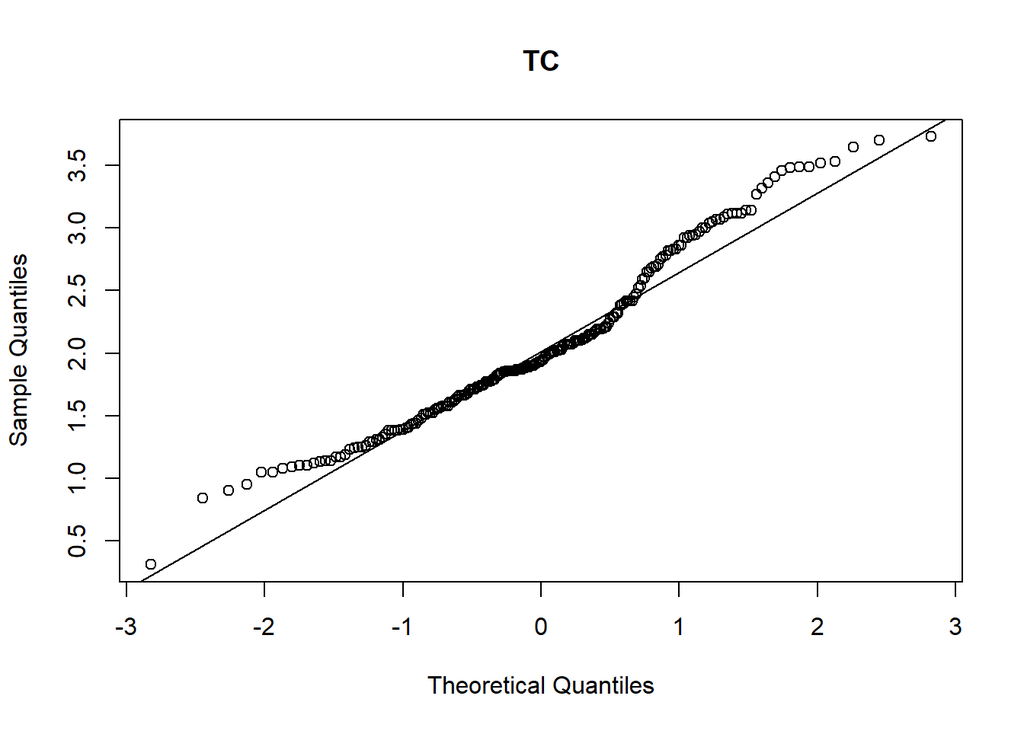

```r
qqnorm(arch241a2$TC, main="TC")
qqline(arch241a2$TC)
```

```r
shapiro.test(arch241a2$TS)
```

```
    Shapiro-Wilk normality test

data:  arch241a2$TS
W = 0.99446, p-value = 0.6335
```

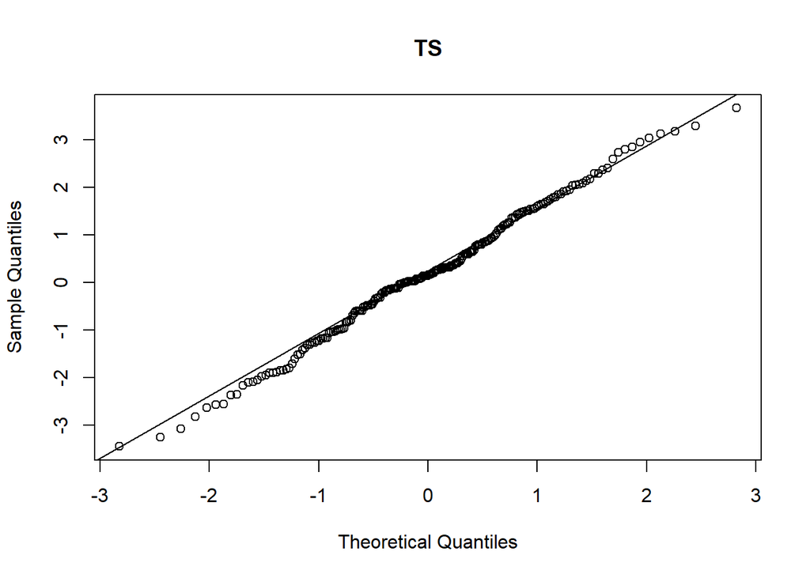

```r
qqnorm(arch241a2$TS, main="TS")
qqline(arch241a2$TS)
```

**Interpretation.** [WRITE 2–3 SENTENCES. Are they normal? Does it matter, and for what?] TC significantly deviates from a normal distribution (p = 1.07^{-4}), and its Q-Q plot also shows deviations from the reference line. In contrast, normality is not rejected for TS (p = 0.63). Non-normality does not matter, but it will matter if TC is used in statistical test that assume normality.

## 6. Does Sex significantly influence TS?

```r
# [WRITE YOUR CODE]
# Then answer this, in your text: Sex is a property of a SUBJECT, and you have
# 30 subjects but 210 rows. What is your real sample size, and what does using
# 210 do to your p-value?
# Try at least two approaches and report whether they agree.

# Approach1: using 210 observations
t.test(
  TS ~ Sex,
  alternative='two.sided',
  conf.level=.99,
  var.equal=FALSE,
  data=arch241a2
)
```

```
    Welch Two Sample t-test

data:  TS by Sex
t = -1.2011, df = 207.13, p-value = 0.2311
alternative hypothesis: true difference in means between group F and group M is not equal to 0
99 percent confidence interval:
 -0.7251169  0.2668311
sample estimates:
mean in group F mean in group M
     0.06352381      0.29266667
```

```r
# Approach 2: using the mean TS of 30 subjects
t.test(
  TS ~ Sex,
  alternative='two.sided',
  conf.level=.99,
  var.equal=FALSE,
  data=summarise(
    group_by(arch241a2, Subject, Sex),
    TS=mean(TS)
  )
)
```

```
    Welch Two Sample t-test

data:  TS by Sex
t = -1.6972, df = 27.748, p-value = 0.1008
alternative hypothesis: true difference in means between group F and group M is not equal to 0
99 percent confidence interval:
 -0.6024610  0.1441753
sample estimates:
mean in group F mean in group M
     0.06352381      0.29266667
```

**Interpretation.** [WRITE 2–3 SENTENCES] Sex is a characteristic of the subject, so the real independent sample size is 30, not 210 observations.  
Treating all observations as independent could ignore the repeated measurements within each subject.

Both approaches show no statistically significant difference in TS between F and M.

## 7. Linear regression: TS as a function of Top

```r
# [WRITE YOUR CODE] Fit the model, then TEST ITS VALIDITY.
# The four assumptions: linearity, constant variance, normal residuals,
# independent observations. Check all four and say which ones hold.


lmTSTop <- lm(TS ~ Top, data=arch241a2)
summary(lmTSTop)
```

```
Call:
lm(formula = TS ~ Top, data = arch241a2)

Residuals:
     Min       1Q   Median       3Q      Max
-2.02656 -0.47667 -0.01664  0.42833  2.28329

Coefficients:
            Estimate Std. Error t value Pr(>|t|)
(Intercept) -7.59900    0.31359  -24.23   <2e-16 ***
Top          0.28502    0.01136   25.09   <2e-16 ***
---
Signif. codes:  0 '***' 0.001 '**' 0.01 '*' 0.05 '.' 0.1 ' ' 1

Residual standard error: 0.6912 on 208 degrees of freedom
Multiple R-squared:  0.7517,    Adjusted R-squared:  0.7505
F-statistic: 629.6 on 1 and 208 DF,  p-value: < 2.2e-16
```

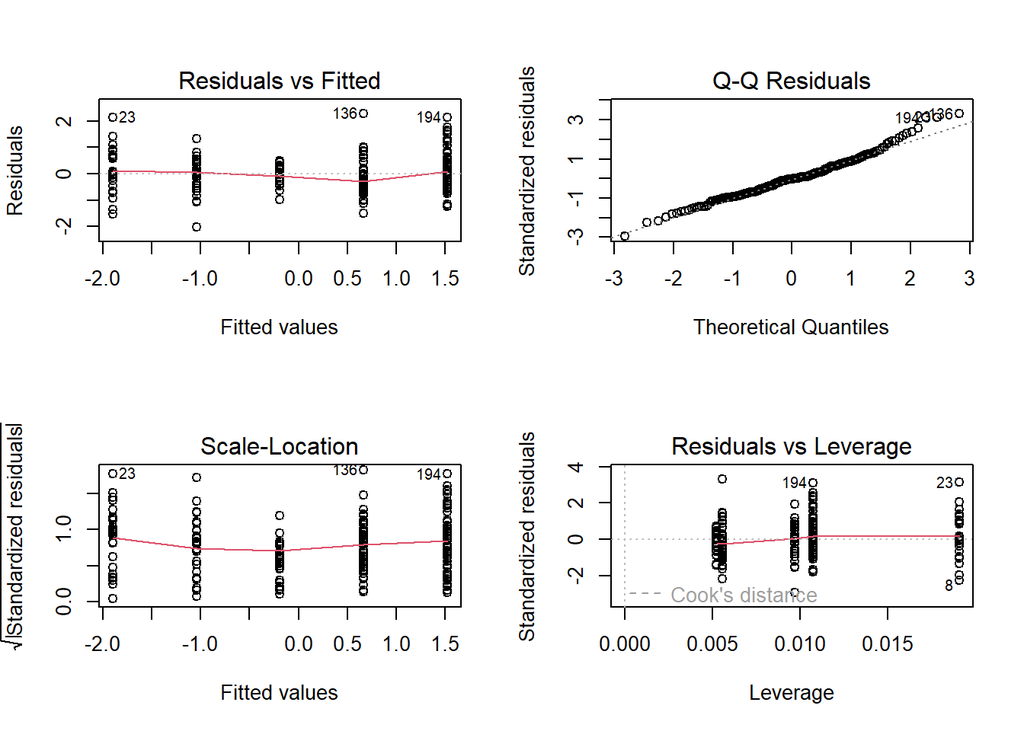

```r
# Diagnostic plots
par(mfrow=c(2,2))
plot(lmTSTop)
```

```r
par(mfrow=c(1,1))

# Normality of residuals
shapiro.test(residuals(lmTSTop))
```

```
    Shapiro-Wilk normality test

data:  residuals(lmTSTop)
W = 0.9819, p-value = 0.008453
```

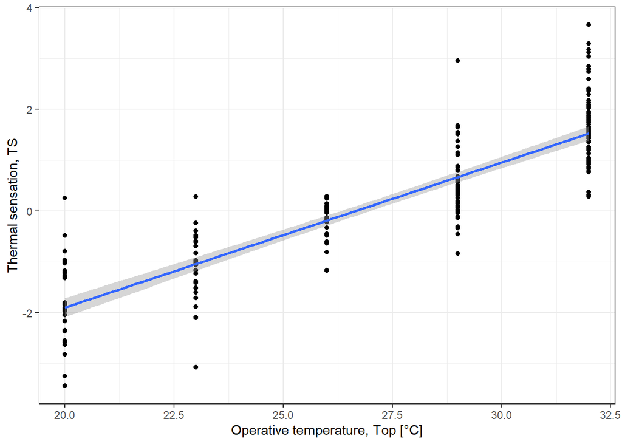

```r
# Regression plot
LinMod <- ggplot(
  arch241a2,
  aes(x=Top, y=TS)
) +
  geom_point() +
  theme_bw() +
  xlab("Operative temperature, Top [°C]") +
  ylab("Thermal sensation, TS")

print(LinMod + geom_smooth(method="lm"))
```

**Interpretation.** [WRITE 2–3 SENTENCES. Report the slope with units, the R², and the neutral temperature — the Top at which predicted TS = 0. Compare it to what PMV predicts.]

The slope is 0.285 with units for each 1 °C increase in Top. The regression model explained 75.2% of the variation in TS.

The predicted neutral temperature was 26.7 °C.

In PMV, it is 25.4 °C.

## 8. Your own research question

**Question:** [WRITE YOUR QUESTION] Does experimental condition have a significant influence on thermal sensation?

```r
# [WRITE YOUR CODE]

AnovaTSExperiment <- aov(TS ~ Experiment, data=arch241a2)
summary(AnovaTSExperiment)
```

```
             Df Sum Sq Mean Sq F value Pr(>F)
Experiment    6 307.80   51.30   112.7 <2e-16 ***
Residuals   203  92.39    0.46
---
Signif. codes:  0 '***' 0.001 '**' 0.01 '*' 0.05 '.' 0.1 ' ' 1
```

```r
by_Experiment <- group_by(arch241a2, Experiment)
summarise(by_Experiment,
          count = n(),
          mean(TS),
          sd(TS))
```

```
# A tibble: 7 × 4
  Experiment count `mean(TS)` `sd(TS)`
  <fct>      <int>      <dbl>    <dbl>
1 A             30     -1.76     0.814
2 B             30     -1.08     0.673
3 C             30      0.361    0.510
4 D             30      0.544    0.708
5 E             30      1.54     0.723
6 F             30      1.84     0.804
7 P             30     -0.196    0.374
```

**Interpretation.** [WRITE 2–3 SENTENCES — the take-away message you would put in a paper.] Thermal sensation differed significantly among experimental conditions. Mean TS ranged from -1.76 in condition A to 1.84 in condition F, showing a clear shift from cooler to warmer thermal sensations across conditions.